# Bayesian view of probability

If I give you a coin and ask you to determine the probability of it landing on head for a single toss. What will you do？ A common way is to flip the coin 20 times(or the amount you considered as enough) and count how many times it comes up with head. Let’s assume it land on heads 15 out of 20 tosses. Then your answer will be the number of heads divided by the number of tosses, which is 15/20. If you take this approach, you view probability in a frequentist way. Frequentist probability is defined as the relative frequency of an event occurs when the process that generate the event is repeated multiple times(Ross, 2018, p. 2). This is usually the definition when we first learned probability in schools. But do people really think about probability in a frequentist view in their daily life? One limitation of this view is that it only assign probability to random repeatable events. However, many things in our life are not random or repeatable yet people still assign probability to them. For example, you might have heard the expression similar to “I am 90% sure that the average height of girls in our class is …”. Even though average height is unknown, but because it is fixed and not random, Frequentist statistician can not assign probability to it. This means that when we are using probability, we do not necessary see it as a frequentist probability. Then what is the other interpretation of probability? Before answering that question, let’s go back to our coin flip example. Here is another approach you might take. Before you toss the coin, you asked me what do I know about this coin. Then I will tell you that it is very likely to be a fair coin. Then will your answer still be 15/20 ? Most likely you will provide an answer closer to 50% if you trust my information because you know a fair coin will have 50% chance to land on head. So even though when you toss the coin it does not land on head half of the time, but because you now think it is likely to be a fair coin, the probability of it landing on head should not be as high as 15/20. This interpretation of probability is known as the Bayesian probability, is a degree of personal belief of a event will happen(Ross, 2018, p. 46). Unlike the frequentist probability derived by performing a large number of experiments, Bayesian probability is calculated using information that change people’s belief. So when you trust my information about the fair coin, it changes your belief of the coin lands on heads. The mathematical way to present the Bayesian probability is shown in the following picture.

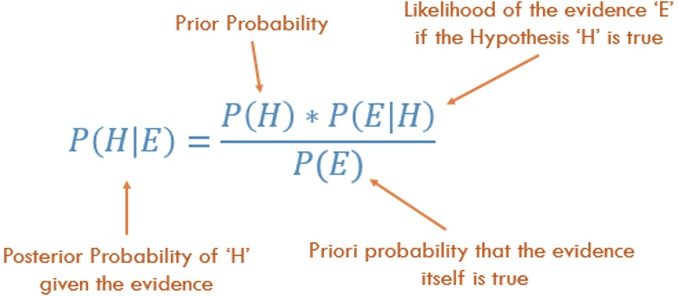

In our coin flip example, your belief of the 50% probability due to my information is called prior probability P(H), which is the probability before you actually toss the coin. Here the result of your coin tosses(15 heads in 20 tosses) is the evidence. Now given that evidence(your toss result), you start to have doubts about the my claim that it is very likely to be a fair coin. You start to wonder how possible is it for a coin to land on head 15 out of 20 times if it is indeed fair. This probability is what we called likelihood of evidence when hypothesis or prior information is correct, which is P(E|H) in the graph. Along with the likelihood of evidence to be true, you will get your answer to my question which is the posterior probability, P(H|E). The way to calculate the probability of evidence, P(E), is by using the Law of Total probability. This will transform P(E)=P(H)P(E|H)+P(F)P(E|F), while P(F)+P(H)=1. The calculation for Bayesian probability might seem tedious and we are not likely to go through the exact formula when we are thinking about the probability of an event in our daily life. However, We do use a simple version of Bayesian. For example, one morning when you are deciding whether you should bring an umbrella when you leave your house. You look at the gloomy sky, looks like it is going to rain. Then you remember that it rained most of the time last week. That information will likely to change your mind from “It might rain” to “It is very likely to rain”. Here the memory from last week is a prior knowledge and when you combine it with the gloomy sky, it changes your belief of actual raining today. So next time when you are talking about probability, why not pause and think for a second which type of probability you are using?

Work cited:

Ross, S. (2018). First Course in Probability. Pearson Education Canada. P2,46.

Source of all picture in order: https://fsmedia.imgix.net/d9/35/70/d3/4572/45fd/9b16/b7eee4f748b7/bayestheorem1png.png?auto=format%2Ccompress&dpr=2&w=492